# Projet ADM total

[figure not shown]

```r
########
afd.Mat.Taille = discrimin(acp.Topo,as.factor(especes$Taille)
                 , scannf = FALSE, nf = 2)

plot(afd.Ecoute.Taille)
```

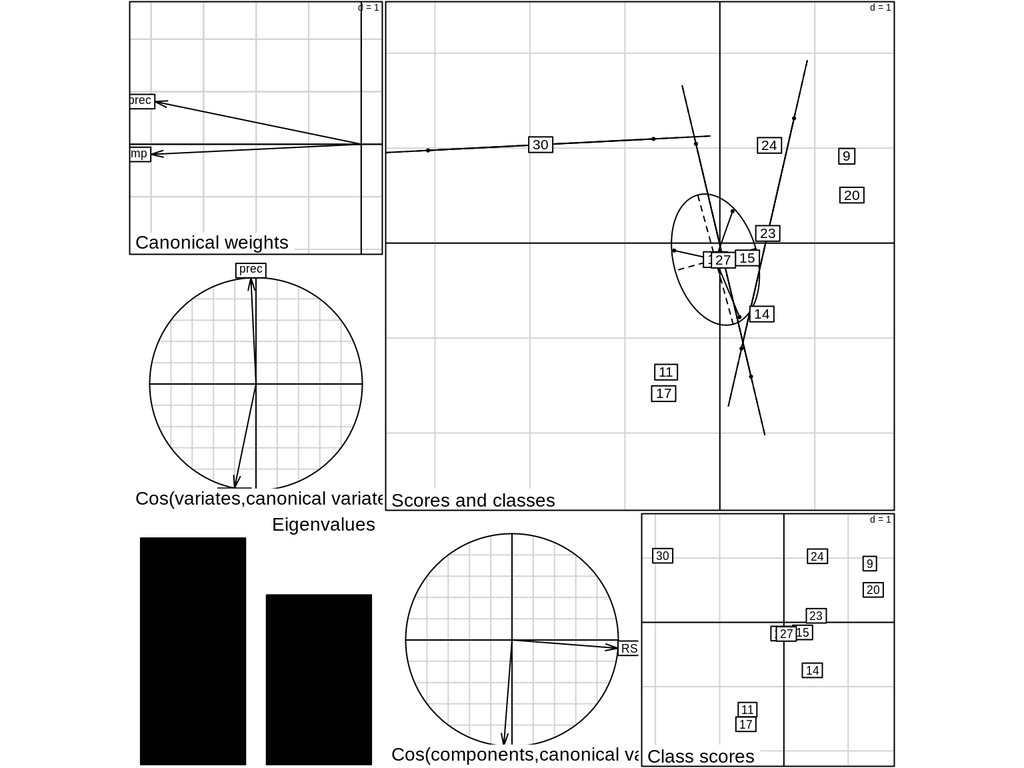

```r
########
afd.CondTopo.Taille = discrimin(acp.CondTopo,as.factor(especes$Taille)
                 , scannf = FALSE, nf = 2)

plot(afd.CondTopo.Taille)
```

#### ==> conclure :

Lieu d’écoute vs Taille des espèces :

> pas de création concluante de classe

12 et 23 peu expliquer par les 2 axes

20 et 24 ont les coordonnées similaires 9 et 30 // (// == pareil qu’au dessus) 11 et 14 // 11, 14 et 20,24 sont opposé

Ocuu vs Taille des espèces :

> toujours aucune classe concluante à part pour grouper le groupe 12 : Moqueur.grivotte

15 peu expliquer par le modèle arbu et hydro sont peu explicatif de notre modèle

l’espèce 23 a tendance a se retrouver en foret avec des grandes surfaces agricole

Frag vs Taille des espèces :

> rien de concluant

Les 4 variables sont explicative mais ont des vélocités colinéaires

l’espèce 30 est très ecot mais très peu heter et lisi

Topo vs Taille des espèces :

> pas de création concluante de classe

Les 2 variables sont explicative mais ont des vélocités colinéaires

CondTopo vs Taille des espèces :

> same

Les 2 variables sont explicative mais ont des vélocités colinéaires

Global : on ne peut pas classer la taille des espèces en fonction de l’environnement

Cependant on voit que on peut séparer les tailles des espèces par l’environnement

# ==== QUESTION 3 ====

–> habitat : urbanisation –> communautés : répartition des espèces

==> impact de l’urbanisation sur la répartition attendues naturelles des espèces –> moins d’espèces 1 ou plus d’espèces 2 en zones urbaines que rurales…

**ANALYSE** : ==> chi² entre commu et habitat$bati ==> ACP(commu[,2:length(commu[1,])]~habitat$bati)

==> conclure : certaines espèces fuient les milieux urbains quand d’autres si refugent

# ==== QUESTION 4 ====

–> habitat : urbanisation –> espèces : taille

==> impact de l’urbanisation sur la taille des oiseaux (diminution de la taille pour se cacher de l’Homme ?)

```r
habitat = read.table("../data/habitat.tsv", sep = "\t",
                     stringsAsFactors = T, header = T, na.strings = T)
habitat = habitat[,-2:-3] # on supprime le qualitatif

especes = read.table("../data/especes.tsv", sep = "\t",
                     stringsAsFactors = T, header = T, na.strings = T)

commu = read.table("../data/communautes.tsv", sep = "\t",
                   stringsAsFactors = T, header = T, na.strings = T)
```

## on vas chercher si ya une corrélation entre la taille et l’espèce de volatile :

### création des subsets par espèces

```r
# Récupération des noms des colonnes correspondant aux espèces (colonnes 2 à 17)
vectNom <- c("Myo", "Gem", "Meh", "Col", "Lon", "Cir", "Euh", "Orc", "Euj", "Cof", "Dep", "Mas", "Maf", "Saa", "Elm", "Tul")

# Création d'une liste vide pour stocker les sous-ensembles
listSubsets = list()
# Parcours de toutes les espèces
for (i in 1:length(vectNom)) {
  especesActu = vectNom[i]
  # Extraction des numéros de lieu (IdPE) où l'espèce a une présence (valeur 1)
  foosubset = commu$IdPE[commu[[especesActu]] == 1]
  listSubsets[[especesActu]] = foosubset
}

# /!\ va faire vla des lignes de variables :
```

```r
for (i in seq_along(vectNom)) {
  subset_name <- paste0(vectNom[i], "habitat")
  assign(subset_name, subset(habitat, IdPE %in% listSubsets[[vectNom[i]]]))

  # Modify column 20 with corresponding 'Taille' value
  temp_df <- get(subset_name)
  temp_df[, 18] <- especes$Taille[i]
  assign(subset_name, temp_df)
}
```

faire les dataframes

on a les positions des oiseaux par espèces dans les n° IDPG

faire les Chi² pour voir si la taille est indépendente chez chaque espèces :

```r
chi_results <- list()
for (nom in vectNom) {
  subset_name <- paste0(nom, "habitat")
  temp_df <- get(subset_name)

  if ("bati" %in% colnames(temp_df)) {  # Ensure 'bati' column exists
    chi_results[[nom]] <- chisq.test(temp_df$bati)
  } else {
    chi_results[[nom]] <- paste("Column 'bati' not found in", subset_name)
  }
}
```

malaise,

on regrope par intervalle de taille

test cor.test entre taille et urbanisation

```r
meanList = c()

meanList = append(meanList, mean(Myohabitat$bati))
meanList = append(meanList, mean(Gemhabitat$bati))
meanList = append(meanList, mean(Mehhabitat$bati))
meanList = append(meanList, mean(Colhabitat$bati))
meanList = append(meanList, mean(Lonhabitat$bati))
meanList = append(meanList, mean(Cirhabitat$bati))
meanList = append(meanList, mean(Euhhabitat$bati))
meanList = append(meanList, mean(Orchabitat$bati))
meanList = append(meanList, mean(Eujhabitat$bati))
meanList = append(meanList, mean(Cofhabitat$bati))
meanList = append(meanList, mean(Dephabitat$bati))
meanList = append(meanList, mean(Mashabitat$bati))
meanList = append(meanList, mean(Mafhabitat$bati))
meanList = append(meanList, mean(Saahabitat$bati))
meanList = append(meanList, mean(Elmhabitat$bati))
meanList = append(meanList, mean(Tulhabitat$bati))
```

on a les moyennes : chi² time :)

### vérification validité cor.test

#### vérification normalité

```r
#normalité :
shapiro.test(meanList)
```

```
##
##  Shapiro-Wilk normality test
##
## data:  meanList
## W = 0.93103, p-value = 0.2532
```

```r
shapiro.test(especes$Taille)
```

```
##
##  Shapiro-Wilk normality test
##
## data:  especes$Taille
## W = 0.91199, p-value = 0.1253
```

données normales

#### vérification linéralité

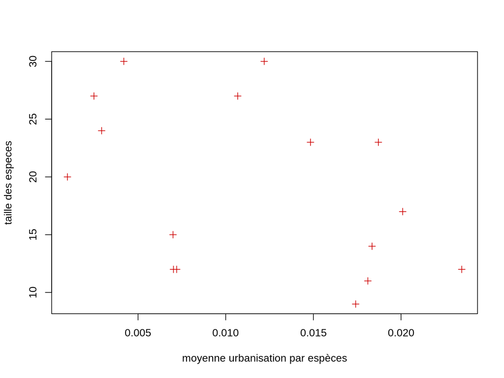

```r
plot(meanList,especes$Taille,
     pch =3, col = "red3",
     ylab = "taille des especes",xlab = "moyenne urbanisation par espèces")
```

Bah pas fou mais globalement avec clémence, on semble voir une tendence à la décroissante

#### test homoscédasticité

```r
library(lmtest)
bptest(meanList~especes$Taille)
```

```
##
##  studentized Breusch-Pagan test
##
## data:  meanList ~ especes$Taille
## BP = 0.34564, df = 1, p-value = 0.5566
```

données homostasiques

Conditions valides : happy

```r
cor.test(especes$Taille,meanList,
         method = "pearson")
```

```
##
##  Pearson's product-moment correlation
##
## data:  especes$Taille and meanList
## t = -1.7395, df = 14, p-value = 0.1039
## alternative hypothesis: true correlation is not equal to 0
## 95 percent confidence interval:
##  -0.75872141  0.09372149
## sample estimates:
##        cor
## -0.4215692
```

```r
cor.test(especes$Taille,meanList,
         method = "kendall")
```

```
##
##  Kendall's rank correlation tau
##
## data:  especes$Taille and meanList
## z = -1.4506, p-value = 0.1469
## alternative hypothesis: true tau is not equal to 0
## sample estimates:
##        tau
## -0.2735942
```

```r
cor.test(especes$Taille,meanList,
         method = "spearman")
```

```
##
##  Spearman's rank correlation rho
##
## data:  especes$Taille and meanList
## S = 958.44, p-value = 0.1153
## alternative hypothesis: true rho is not equal to 0
## sample estimates:
##        rho
## -0.4094659
```

t = -1.7395, df = 14, p-value = 0.1039 alternative hypothesis: true correlation is not equal to 0

95 percent confidence interval: -0.75872141 0.09372149

sample estimates: cor -0.4215692

# ==== QUESTION 5 ====

–> habitat : urbanisation –> espèces : protégée ou non ?

==> est-ce que les oiseaux protégés sont davantages présents dans les milieux urbains : protection intense par l’Homme, abondance de nourriture, absence de prédateurs, habitats cachés et sécuritaires…

## ANALYSE :

==> chi² entre habitat `bati et especes` IUCN

```r
vectCol = c("IdPE","agri","arbu","prai","foret","bati")
habitaEnv.subset = subset(habitat,select = vectCol)
```

## on vas chercher si ya une corrélation entre espèces protégé et l’espèce de volatile :

```r
# Récupération des noms des colonnes correspondant aux espèces (colonnes 2 à 17)
vectNom <- c("Myo", "Gem", "Meh", "Col", "Lon", "Cir", "Euh", "Orc", "Euj", "Cof", "Dep", "Mas", "Maf", "Saa", "Elm", "Tul")

# Création d'une liste vide pour stocker les sous-ensembles
listSubsets = list()
# Parcours de toutes les espèces
for (i in 1:length(vectNom)) {
  especesActu = vectNom[i]
  # Extraction des numéros de lieu (IdPE) où l'espèce a une présence (valeur 1)
  foosubset = commu$IdPE[commu[[especesActu]] == 1]
  listSubsets[[especesActu]] = foosubset
}

# /!\ va faire vla des lignes de variables :
```

on va faire comme a la Q4 mais avec plus de variable

```r
# Liste des noms d'habitat
habitat_names <- c("Myohabitat", "Gemhabitat", "Mehhabitat", "Colhabitat", "Lonhabitat",
                   "Cirhabitat", "Euhhabitat", "Orchabitat", "Eujhabitat", "Cofhabitat",
                   "Dephabitat", "Mashabitat", "Mafhabitat", "Saahabitat", "Elmhabitat", "Tulhabitat")

# liste des diminutif des noms
vectNom <- c("Myo", "Gem", "Meh", "Col", "Lon", "Cir", "Euh", "Orc", "Euj",
             "Cof", "Dep", "Mas", "Maf", "Saa", "Elm", "Tul")

# Liste des colonnes d'intérêt
vectCol <- c("agri", "arbu", "prai", "foret", "bati")

# Initialisation d'une liste pour stocker les données
meanList <- data.frame(matrix(ncol = length(vectCol) + 1, nrow = length(habitat_names)))

# Nommer les colonnes du dataframe
colnames(meanList) <- c("habitat", vectCol)

# Remplir le dataframe
for (i in seq_along(habitat_names)) {
  habitat <- habitat_names[i]
  habitat_data <- get(habitat)  # Récupération du dataframe

  # Calcul des moyennes pour chaque colonne d'intérêt
  mean_values <- sapply(vectCol, function(col) mean(habitat_data[[col]], na.rm = TRUE))

  # Stockage des résultats
  meanList[i, ] <- c(habitat, mean_values)
}

# Convertir la colonne 'habitat' en facteur ou caractère
meanList$habitat <- as.character(vectNom)

# Affichage du résultat
meanList = data.frame(meanList)

# Conversion des colonnes en numérique car bozo est char
meanList[,-1] <- lapply(meanList[,-1], as.numeric)
```

faire les dataframes

#### 1 faire l’ACP

```r
acp.meanhabi = dudi.pca(meanList[,-1],
         center = T, scale = T,
         scannf = FALSE, nf = 2)
```

#### 2 faire une AFC

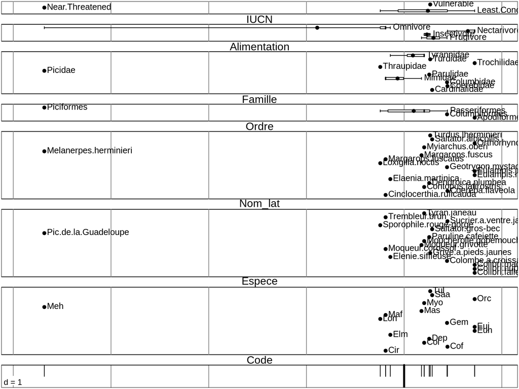

```r
acm.espèces = dudi.acm(as.data.frame(especes[-6]),
                       scannf = FALSE, nf = 2)
boxplot(acm.espèces)
```

```r
coinertie = coinertia(acm.espèces,acp.meanhabi,
                      scannf = FALSE, nf = 2); summary(coinertie)
```

```
## Coinertia analysis
##
## Class: coinertia dudi
## Call: coinertia(dudiX = acm.espèces, dudiY = acp.meanhabi, scannf = FALSE,
##     nf = 2)
##
## Total inertia: 2.857
##
## Eigenvalues:
##       Ax1       Ax2       Ax3       Ax4       Ax5
## 2.2849117 0.5220622 0.0381169 0.0118412 0.0003562
##
## Projected inertia (%):
##      Ax1      Ax2      Ax3      Ax4      Ax5
## 79.96784 18.27125  1.33403  0.41442  0.01247
##
## Cumulative projected inertia (%):
##     Ax1   Ax1:2   Ax1:3   Ax1:4   Ax1:5
##   79.97   98.24   99.57   99.99  100.00
##
## Eigenvalues decomposition:
##         eig     covar       sdX      sdY      corr
## 1 2.2849117 1.5115925 0.7922154 1.977465 0.9649009
## 2 0.5220622 0.7225387 0.7384785 1.006445 0.9721502
##
## Inertia & coinertia X (acm.espèces):
##      inertia      max     ratio
## 1  0.6276052 0.891648 0.7038711
## 12 1.1729557 1.729395 0.6782461
##
## Inertia & coinertia Y (acp.meanhabi):
##     inertia      max     ratio
## 1  3.910367 3.919180 0.9977513
## 12 4.923298 4.923885 0.9998808
##
## RV:
##  0.2988435
```

[figure not shown]

```r
s.corcircle(coinertie$li)
```

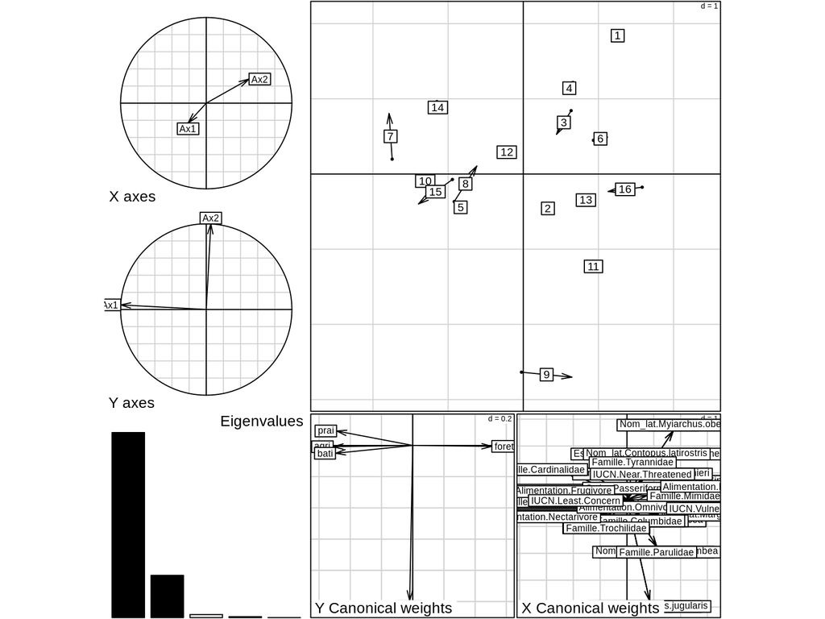

```r
plot(coinertie)
```

on arrive a séparer les espèces en fonctions decès variables environnementales

X = acm Y = acp

==> conclure :

l’ACP explique super bien la co-inertie l’ACM moins mais explique quand même les 2 axes

Les 2 ont une bonne corrélation car les projection de tabX et tabY (les projections des 2 axes) sont très proches.